# Attitudes Regarding the Assignment Process Among Navy Medical Corps Officers

Date: 2023-04-06

This report covers the survey about attitudes collected by Richard Childers, MD and Joel Schofer, MD.

Overall satisfaction was treated as a continuous response variable in a multiple regression. The best fitting model included the three predictor variables of (a) specialty type, (b) officer rank, and (c) billet category, and no interaction terms. Additional variables such as (d) bonus pay, (e) deployment rate, and (f) staffing status did not improve the model fit significantly, and therefore were removed.

Among the five levels in billet category, CONUS MTF had the highest values of satisfaction, and served as the reference group. The CONUS Operational, OCONUS MTF, and Non-operational/non-clinical types were roughly .4 units less satisfied than CONUS MTF (after holding the other two predictors constant). Similarly, physicians currently assigned to OCONUS operational were 1.1 units less satisfied than CONUS MTF.

Among the five levels in specialty type, the non-surgical physicians were most satisfied, and served as the reference group. Residents were .2 units less satisfied, which was not significantly different. However, the difference was significant between the nonsurgical type and the surgical (.3 units), family practice (.4 units) and operational (.7 units) types.

Officer rank was a continuous variable and had a significant positive slope: satisfaction increased with seniority. Note that this does not necessarily mean an officer is expected to grow more satisfied as seniority increases; an alternate explanation is that less-satisfied officers leave the Navy while the more-satisfied officer remain and are promoted. Longitudinal studies are needed to evaluate these competing explanations.

We were comfortable treating the 5-point Likert outcome as a continuous variable in the linear regression, after inspecting the graphs of frequencies and model diagnostics. Thus we are making the assumption that the perceived distance between values 1 and 2 are roughly equivalent to the distance between values 4 and 5. We performed ordered logistic regression that treats the outcome as an ordinal variable, which supported similar conclusions about the roles of the three predictors. We chose to report the conventional regression for ease of interpretability.

# 1 Summary

## 1.1 Notes

1. The current report covers 951 responses.
2. We excluded 17 cases because their orders preceded the year 2012 and 26 cases because the `year_executed_order` value was missing.

## 1.2 Unanswered Questions

## 1.3 Answered Questions

# 2 Histograms

## 2.1 Univariate

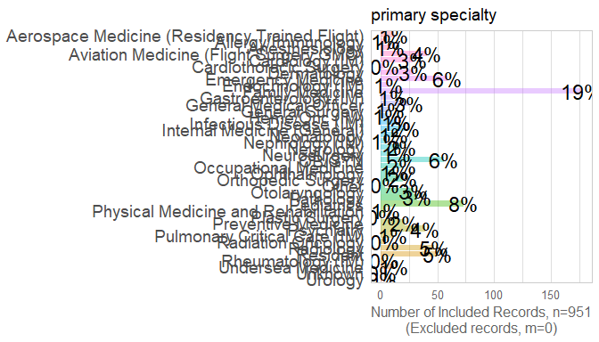

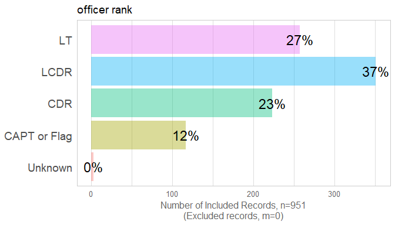

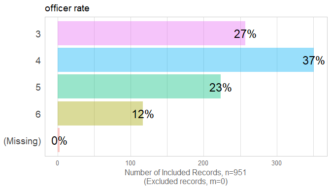

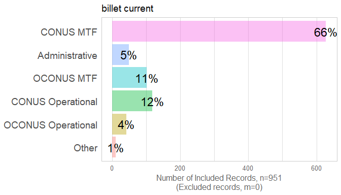

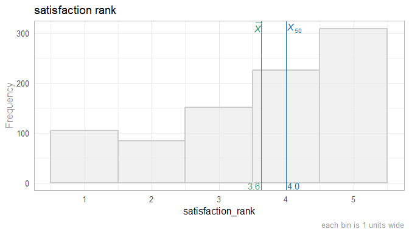

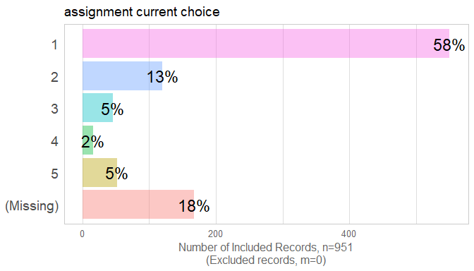

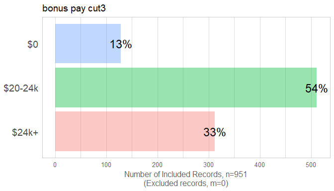

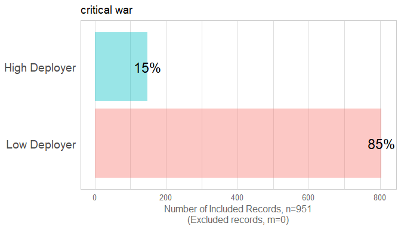

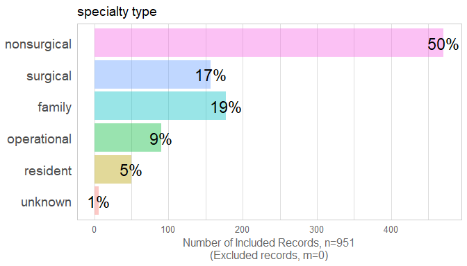

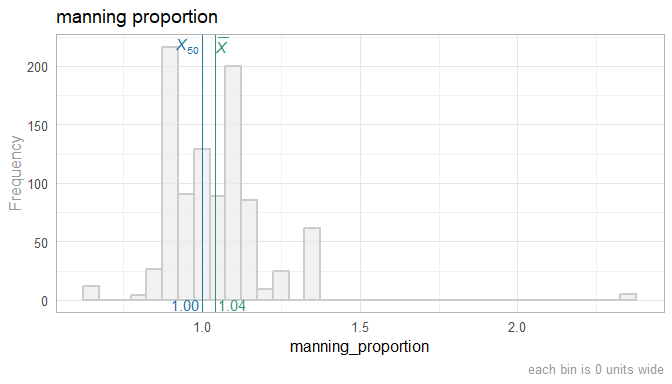

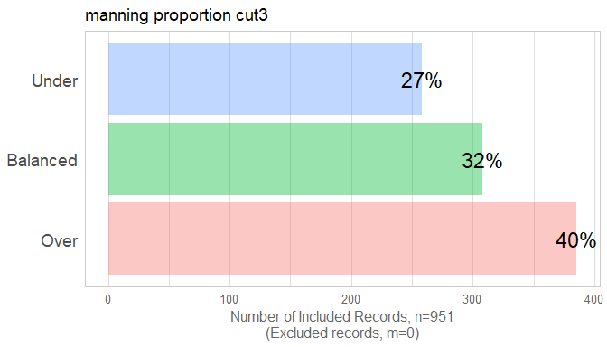

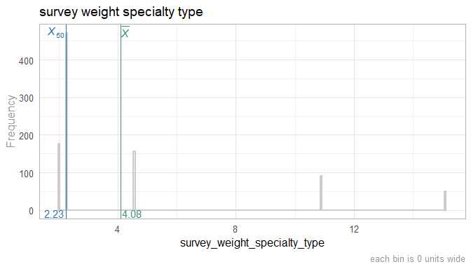

[1 more figures not shown]

```
Satisfaction summary
```

```
   Min. 1st Qu.  Median    Mean 3rd Qu.    Max.    NA's
   1.00    3.00    4.00    3.63    5.00    5.00      79
```

```
Satisfaction summary (emergency medicine only)
```

```
   Min. 1st Qu.  Median    Mean 3rd Qu.    Max.    NA's
  1.000   3.000   4.000   3.759   5.000   5.000       5
```

```
Counts by bonus pay & specialty
```

| bonus_pay_cut4 | specialty_type | n |
| --- | --- | --- |
| $0 | operational | 78 |
| $0 | resident | 50 |
| $20-24k | nonsurgical | 322 |
| $20-24k | family | 177 |
| $20-24k | operational | 12 |
| $24-32k | nonsurgical | 70 |
| $24-32k | surgical | 109 |
| $24-32k | unknown | 6 |
| 32k+ | nonsurgical | 79 |
| 32k+ | surgical | 48 |

# 3 Survey Response

```
Overall unweighted mean satisfaction:
```

```
[1] 3.629587
```

```
Overall weighted mean satisfaction:
```

```
                    mean    SE
satisfaction_rank 3.4141 0.056
```

```
`specialty_type` unweighted mean satisfaction:
```

```
# A tibble: 6 × 2
  specialty_type satisfaction_rank
  <fct>                      <dbl>
1 nonsurgical                 3.92
2 surgical                    3.68
3 family                      3.35
4 operational                 2.66
5 resident                    3.52
6 unknown                     3.4
```

```
`specialty_type` weighted mean satisfaction:
```

```
# A tibble: 5 × 3
  specialty_type satisfaction_rank     se
  <fct>                      <dbl>  <dbl>
1 nonsurgical                 3.92 0.0509
2 surgical                    3.68 0.0925
3 family                      3.35 0.0963
4 operational                 2.66 0.140
5 resident                    3.52 0.167
```

```
`officer_rank` unweighted mean satisfaction:
```

```
# A tibble: 5 × 2
  officer_rank satisfaction_rank
  <fct>                    <dbl>
1 LT                        3.14
2 LCDR                      3.59
3 CDR                       3.93
4 CAPT or Flag              4.13
5 Unknown                   2.5
```

```
`officer_rank` weighted mean satisfaction:
```

```
# A tibble: 5 × 3
  officer_rank satisfaction_rank     se
  <fct>                    <dbl>  <dbl>
1 LT                        2.93 0.103
2 LCDR                      3.50 0.0868
3 CDR                       3.96 0.0771
4 CAPT or Flag              4.02 0.151
5 Unknown                   1    0
```

```
`billet_current` unweighted mean satisfaction:
```

```
# A tibble: 6 × 2
  billet_current     satisfaction_rank
  <fct>                          <dbl>
1 CONUS MTF                       3.85
2 Administrative                  3.65
3 OCONUS MTF                      3.41
4 CONUS Operational               3.12
5 OCONUS Operational              2.45
6 Other                           4
```

```
`billet_current` weighted mean satisfaction:
```

```
# A tibble: 6 × 3
  billet_current     satisfaction_rank     se
  <fct>                          <dbl>  <dbl>
1 CONUS MTF                       3.70 0.0625
2 Administrative                  3.33 0.275
3 OCONUS MTF                      3.50 0.133
4 CONUS Operational               2.94 0.145
5 OCONUS Operational              2.16 0.231
6 Other                           3.78 0.418
```

# 4 Relationships between Outcomes

|  | satisfaction rank | transparency rank | favoritism rank | assignment current choice |
| --- | --- | --- | --- | --- |
| satisfaction_rank | 1.000 | 0.771 | 0.486 | -0.519 |
| transparency_rank | 0.771 | 1.000 | 0.488 | -0.405 |
| favoritism_rank | 0.486 | 0.488 | 1.000 | -0.325 |
| assignment_current_choice | -0.519 | -0.405 | -0.325 | 1.000 |

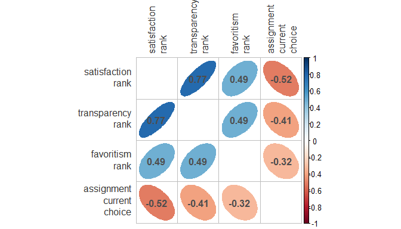

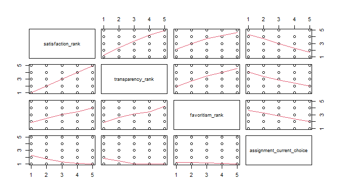

# 5 Analyses - 1 Predictor

## 5.1 By Rank

### 5.1.1 satisfaction_rank

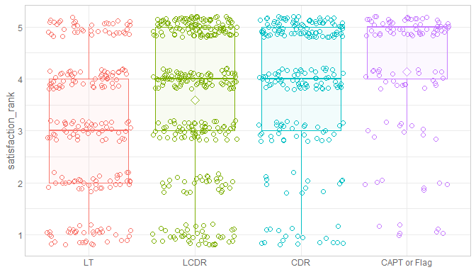

Data:`ds`  
Formula:`~ satisfaction_rank 1 + officer_rate_f`

| term | estimate | std.error | statistic | p.value |
| --- | --- | --- | --- | --- |
| (Intercept) | 3.1361502 | 0.0903269 | 34.720017 | 0.00e+00 |
| officer_rate_f4 | 0.4547589 | 0.1158670 | 3.924834 | 9.37e-05 |
| officer_rate_f5 | 0.7953566 | 0.1268635 | 6.269388 | 0.00e+00 |
| officer_rate_f6 | 0.9934794 | 0.1557247 | 6.379715 | 0.00e+00 |

| r.squared | adj.r.squared | sigma | statistic | p.value | df | logLik | AIC | BIC | deviance | df.residual | nobs |
| --- | --- | --- | --- | --- | --- | --- | --- | --- | --- | --- | --- |
| 0.0619066 | 0.0586569 | 1.318277 | 19.04967 | 0 | 3 | -1472.875 | 2955.751 | 2979.593 | 1504.982 | 866 | 870 |

## 5.2 By Specialty Type

### 5.2.1 satisfaction_rank

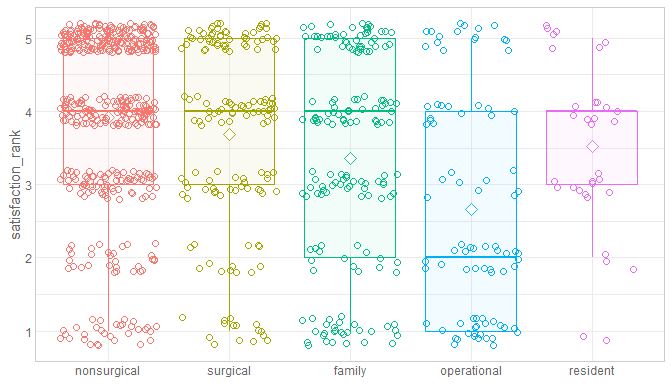

Data:`[ ds ds$specialty_type != “unknown”`  
Formula:

```
 ~
satisfaction_rank 1 + specialty_type
```

| term | estimate | std.error | statistic | p.value |
| --- | --- | --- | --- | --- |
| (Intercept) | 3.9172414 | 0.0625729 | 62.602823 | 0.0000000 |
| specialty_typesurgical | -0.2326776 | 0.1238796 | -1.878257 | 0.0606834 |
| specialty_typefamily | -0.5635828 | 0.1195853 | -4.712809 | 0.0000028 |
| specialty_typeoperational | -1.2544507 | 0.1540125 | -8.145121 | 0.0000000 |
| specialty_typeresident | -0.4020899 | 0.2356418 | -1.706360 | 0.0883012 |

| r.squared | adj.r.squared | sigma | statistic | p.value | df | logLik | AIC | BIC | deviance | df.residual | nobs |
| --- | --- | --- | --- | --- | --- | --- | --- | --- | --- | --- | --- |
| 0.0811978 | 0.0769342 | 1.305062 | 19.04449 | 0 | 4 | -1458.551 | 2929.103 | 2957.693 | 1468.146 | 862 | 867 |

## 5.3 By Bonus Pay

### 5.3.1 satisfaction_rank

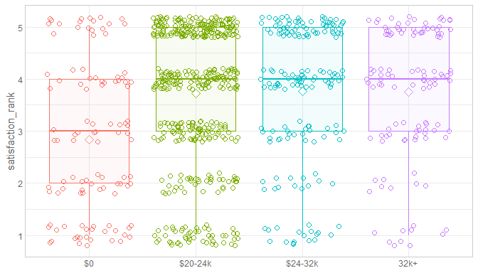

Data:`ds`  
Formula:`~ satisfaction_rank 1 + bonus_pay_cut4`

| term | estimate | std.error | statistic | p.value |
| --- | --- | --- | --- | --- |
| (Intercept) | 2.8411215 | 0.1285699 | 22.097867 | 0e+00 |
| bonus_pay_cut4$20-24k | 0.8846169 | 0.1423437 | 6.214653 | 0e+00 |
| bonus_pay_cut4$24-32k | 0.9289934 | 0.1633872 | 5.685841 | 0e+00 |
| bonus_pay_cut432k+ | 0.9110153 | 0.1778978 | 5.121004 | 4e-07 |

| r.squared | adj.r.squared | sigma | statistic | p.value | df | logLik | AIC | BIC | deviance | df.residual | nobs |
| --- | --- | --- | --- | --- | --- | --- | --- | --- | --- | --- | --- |
| 0.0472242 | 0.0439312 | 1.329938 | 14.34077 | 0 | 3 | -1483.945 | 2977.89 | 3001.744 | 1535.262 | 868 | 872 |

## 5.4 By Assignment Current Choice

### 5.4.1 satisfaction_rank

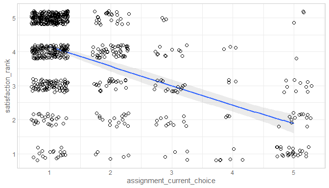

Data:`ds`  
Formula:

```
 ~ satisfaction_rank 1 +
assignment_current_choice
```

| term | estimate | std.error | statistic | p.value |
| --- | --- | --- | --- | --- |
| (Intercept) | 4.7192430 | 0.0674241 | 69.99342 | 0 |
| assignment_current_choice | -0.5721764 | 0.0342102 | -16.72533 | 0 |

| r.squared | adj.r.squared | sigma | statistic | p.value | df | logLik | AIC | BIC | deviance | df.residual | nobs |
| --- | --- | --- | --- | --- | --- | --- | --- | --- | --- | --- | --- |
| 0.2693047 | 0.268342 | 1.074932 | 279.7366 | 0 | 1 | -1133.799 | 2273.598 | 2287.502 | 877.0091 | 759 | 761 |

## 5.5 By Manning Proportion

### 5.5.1 manning_proportion

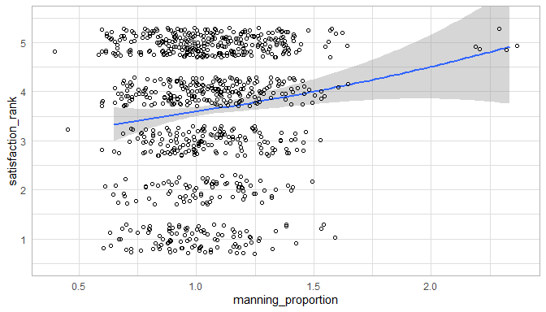

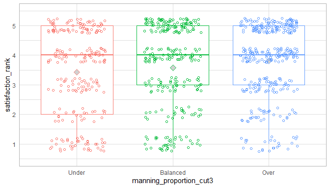

## 5.6 By Critical War

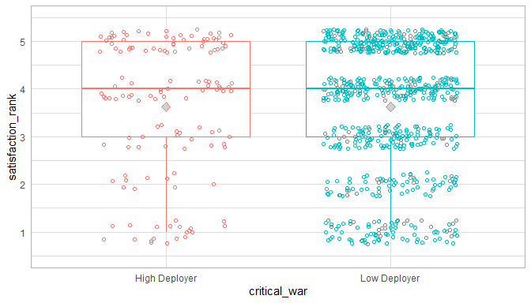

## 5.7 By Billet Current

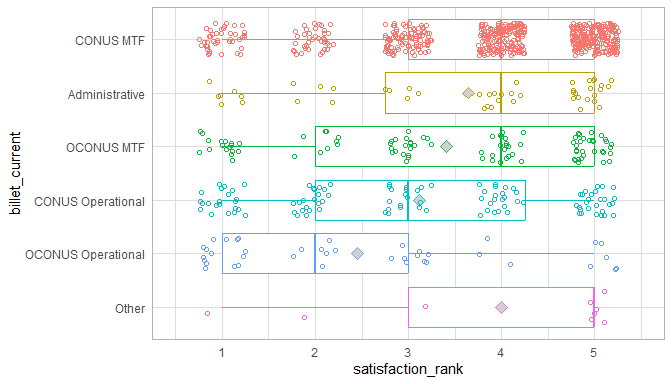

Data:`ds`  
Formula:`~ satisfaction_rank 1 + billet_current`

| term | estimate | std.error | statistic | p.value |
| --- | --- | --- | --- | --- |
| (Intercept) | 3.8472469 | 0.0553450 | 69.5139096 | 0.0000000 |
| billet_currentAdministrative | -0.2014136 | 0.1974596 | -1.0200240 | 0.3080020 |
| billet_currentOCONUS MTF | -0.4372469 | 0.1425066 | -3.0682562 | 0.0022201 |
| billet_currentCONUS Operational | -0.7311755 | 0.1358693 | -5.3814634 | 0.0000001 |
| billet_currentOCONUS Operational | -1.3972469 | 0.2148854 | -6.5022872 | 0.0000000 |
| billet_currentOther | 0.1527531 | 0.4412199 | 0.3462063 | 0.7292718 |

| r.squared | adj.r.squared | sigma | statistic | p.value | df | logLik | AIC | BIC | deviance | df.residual | nobs |
| --- | --- | --- | --- | --- | --- | --- | --- | --- | --- | --- | --- |
| 0.0731888 | 0.0678376 | 1.313205 | 13.67732 | 0 | 5 | -1471.899 | 2957.797 | 2991.193 | 1493.423 | 866 | 872 |

# 6 Analyses - 2 Predictors

## 6.1 By Rank and Specialty Type

### 6.1.1 satisfaction_rank

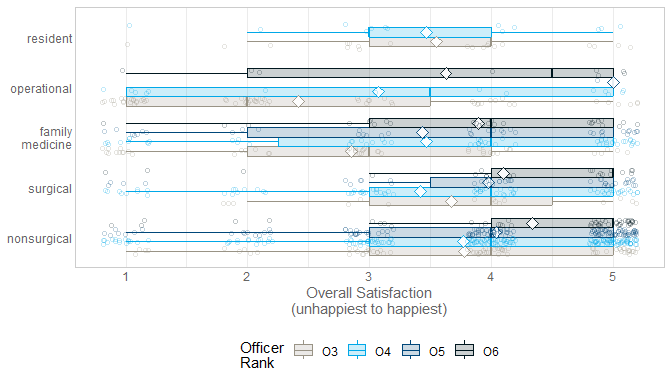

Data:`[ ds ds$specialty_type != “unknown”`  
Formula:

```
 ~
satisfaction_rank 1 + officer_rate_f * specialty_type
```

| term | estimate | std.error | statistic | p.value |
| --- | --- | --- | --- | --- |
| (Intercept) | 3.7794118 | 0.1553781 | 24.3239628 | 0.0000000 |
| officer_rate_f4 | -0.0092968 | 0.1832411 | -0.0507355 | 0.9595483 |
| officer_rate_f5 | 0.2560492 | 0.1891705 | 1.3535366 | 0.1762449 |
| officer_rate_f6 | 0.5539216 | 0.2373440 | 2.3338342 | 0.0198372 |
| specialty_typesurgical | -0.1127451 | 0.3654966 | -0.3084710 | 0.7577997 |
| specialty_typefamily | -0.9315857 | 0.2446039 | -3.8085478 | 0.0001499 |
| specialty_typeoperational | -1.3667134 | 0.2240553 | -6.0998925 | 0.0000000 |
| specialty_typeresident | -0.2294118 | 0.3259239 | -0.7038814 | 0.4816999 |
| officer_rate_f4:specialty_typesurgical | -0.2384509 | 0.4064573 | -0.5866567 | 0.5575904 |
| officer_rate_f5:specialty_typesurgical | 0.0516431 | 0.4328109 | 0.1193202 | 0.9050499 |
| officer_rate_f6:specialty_typesurgical | -0.1253501 | 0.4939158 | -0.2537885 | 0.7997205 |
| officer_rate_f4:specialty_typefamily | 0.6244337 | 0.3157016 | 1.9779237 | 0.0482607 |
| officer_rate_f5:specialty_typefamily | 0.3285571 | 0.3403586 | 0.9653265 | 0.3346565 |
| officer_rate_f6:specialty_typefamily | 0.4871412 | 0.3909269 | 1.2461183 | 0.2130651 |
| officer_rate_f4:specialty_typeoperational | 0.6680270 | 0.4205932 | 1.5882972 | 0.1125919 |
| officer_rate_f5:specialty_typeoperational | 2.3312524 | 1.3051914 | 1.7861383 | 0.0744341 |
| officer_rate_f6:specialty_typeoperational | 0.6583800 | 0.5362841 | 1.2276701 | 0.2199115 |
| officer_rate_f4:specialty_typeresident | -0.0791647 | 0.4918785 | -0.1609436 | 0.8721761 |
| officer_rate_f5:specialty_typeresident | NA | NA | NA | NA |
| officer_rate_f6:specialty_typeresident | NA | NA | NA | NA |

| r.squared | adj.r.squared | sigma | statistic | p.value | df | logLik | AIC | BIC | deviance | df.residual | nobs |
| --- | --- | --- | --- | --- | --- | --- | --- | --- | --- | --- | --- |
| 0.1249664 | 0.1074244 | 1.281281 | 7.123859 | 0 | 17 | -1434.353 | 2906.706 | 2997.22 | 1392.145 | 848 | 866 |

Data:`[ ds ds$specialty_type != “unknown”`  
Formula:

```
 ~ satisfaction_rank 1 + officer_rate_f +
specialty_type
```

| term | estimate | std.error | statistic | p.value |
| --- | --- | --- | --- | --- |
| (Intercept) | 3.6060419 | 0.1138533 | 31.6726901 | 0.0000000 |
| officer_rate_f4 | 0.1894040 | 0.1227398 | 1.5431344 | 0.1231669 |
| officer_rate_f5 | 0.4624532 | 0.1364136 | 3.3900819 | 0.0007306 |
| officer_rate_f6 | 0.7806986 | 0.1587342 | 4.9182747 | 0.0000010 |
| specialty_typesurgical | -0.2466207 | 0.1222314 | -2.0176535 | 0.0439382 |
| specialty_typefamily | -0.5476117 | 0.1188297 | -4.6083747 | 0.0000047 |
| specialty_typeoperational | -1.0520849 | 0.1656575 | -6.3509630 | 0.0000000 |
| specialty_typeresident | -0.1655041 | 0.2383040 | -0.6945081 | 0.4875516 |

| r.squared | adj.r.squared | sigma | statistic | p.value | df | logLik | AIC | BIC | deviance | df.residual | nobs |
| --- | --- | --- | --- | --- | --- | --- | --- | --- | --- | --- | --- |
| 0.113058 | 0.1058219 | 1.282431 | 15.62411 | 0 | 7 | -1440.206 | 2898.412 | 2941.287 | 1411.091 | 858 | 866 |

## 6.2 By Rank and Assignment Current Choice

## 6.3 By Rank and Bonus Pay

### 6.3.1 satisfaction_rank

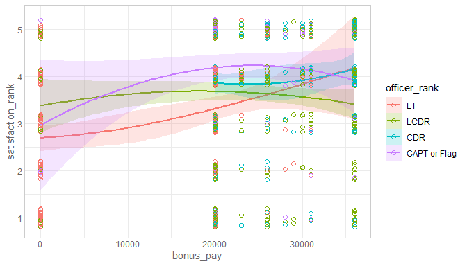

Data:`ds`  
Formula:

```
 ~ satisfaction_rank 1 + officer_rate_f +
bonus_pay
```

| term | estimate | std.error | statistic | p.value |
| --- | --- | --- | --- | --- |
| (Intercept) | 2.9244122 | 0.1132714 | 25.817747 | 0.0000000 |
| officer_rate_f4 | 0.2934115 | 0.1267040 | 2.315724 | 0.0208064 |
| officer_rate_f5 | 0.6032909 | 0.1408814 | 4.282261 | 0.0000206 |
| officer_rate_f6 | 0.8478220 | 0.1620620 | 5.231467 | 0.0000002 |
| bonus_pay | 0.0000158 | 0.0000051 | 3.072155 | 0.0021917 |

| r.squared | adj.r.squared | sigma | statistic | p.value | df | logLik | AIC | BIC | deviance | df.residual | nobs |
| --- | --- | --- | --- | --- | --- | --- | --- | --- | --- | --- | --- |
| 0.0720318 | 0.0677406 | 1.311901 | 16.786 | 0 | 4 | -1468.155 | 2948.309 | 2976.92 | 1488.738 | 865 | 870 |

Data:`ds`  
Formula:

```
 ~ satisfaction_rank 1 +
officer_rate_f * bonus_pay
```

| term | estimate | std.error | statistic | p.value |
| --- | --- | --- | --- | --- |
| (Intercept) | 2.6738295 | 0.1412220 | 18.933520 | 0.0000000 |
| officer_rate_f4 | 0.9876528 | 0.2498733 | 3.952615 | 0.0000836 |
| officer_rate_f5 | 0.8154021 | 0.3806246 | 2.142274 | 0.0324510 |
| officer_rate_f6 | 1.1783927 | 0.4842708 | 2.433334 | 0.0151628 |
| bonus_pay | 0.0000345 | 0.0000081 | 4.232110 | 0.0000256 |
| officer_rate_f4:bonus_pay | -0.0000374 | 0.0000115 | -3.245845 | 0.0012162 |
| officer_rate_f5:bonus_pay | -0.0000172 | 0.0000157 | -1.096670 | 0.2730919 |
| officer_rate_f6:bonus_pay | -0.0000222 | 0.0000213 | -1.042449 | 0.2974956 |

| r.squared | adj.r.squared | sigma | statistic | p.value | df | logLik | AIC | BIC | deviance | df.residual | nobs |
| --- | --- | --- | --- | --- | --- | --- | --- | --- | --- | --- | --- |
| 0.0832837 | 0.0758394 | 1.30619 | 11.18754 | 0 | 7 | -1462.848 | 2943.696 | 2986.612 | 1470.687 | 862 | 870 |

`Analysis of Variance Table`

Model 1: satisfaction_rank ~ 1 + officer_rate_f + bonus_pay Model 2: satisfaction_rank ~ 1 + officer_rate_f * bonus_pay Res.Df RSS Df Sum of Sq F Pr(>F) 1 865 1488.7  
2 862 1470.7 3 18.052 3.5268 0.01461

## 6.4 By Billet Current and Critical War

### 6.4.1 satisfaction_rank

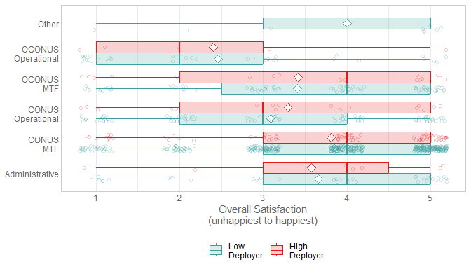

Data:`ds`  
Formula:

```
 ~ satisfaction_rank 1 + billet_current +
critical_war
```

| term | estimate | std.error | statistic | p.value |
| --- | --- | --- | --- | --- |
| (Intercept) | 3.8377622 | 0.1180247 | 32.5166107 | 0.0000000 |
| billet_currentAdministrative | -0.2015313 | 0.1975770 | -1.0200137 | 0.3080071 |
| billet_currentOCONUS MTF | -0.4370929 | 0.1425983 | -3.0652035 | 0.0022428 |
| billet_currentCONUS Operational | -0.7312263 | 0.1359483 | -5.3787096 | 0.0000001 |
| billet_currentOCONUS Operational | -1.3975988 | 0.2150434 | -6.4991486 | 0.0000000 |
| billet_currentOther | 0.1509960 | 0.4418948 | 0.3417011 | 0.7326588 |
| critical_warLow Deployer | 0.0112418 | 0.1235363 | 0.0910001 | 0.9275136 |

| r.squared | adj.r.squared | sigma | statistic | p.value | df | logLik | AIC | BIC | deviance | df.residual | nobs |
| --- | --- | --- | --- | --- | --- | --- | --- | --- | --- | --- | --- |
| 0.0731976 | 0.0667689 | 1.313958 | 11.38609 | 0 | 6 | -1471.894 | 2959.789 | 2997.955 | 1493.409 | 865 | 872 |

## 6.5 By Bonus_pay and Manning_proportion

### 6.5.1 satisfaction_rank

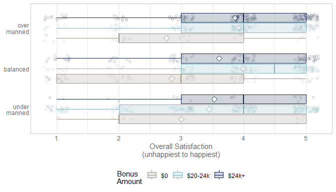

Data:`ds`  
Formula:

```
 ~ satisfaction_rank 1 +
manning_proportion_cut3 + bonus_pay_cut3
```

| term | estimate | std.error | statistic | p.value |
| --- | --- | --- | --- | --- |
| (Intercept) | 2.4680836 | 0.1647969 | 14.976514 | 0.0000000 |
| manning_proportion_cut3Balanced | 0.3928698 | 0.1259855 | 3.118373 | 0.0018786 |
| manning_proportion_cut3Over | 0.4651373 | 0.1209922 | 3.844358 | 0.0001297 |
| bonus_pay_cut3$20-24k | 1.0172580 | 0.1493703 | 6.810311 | 0.0000000 |
| bonus_pay_cut3$24k+ | 0.8796862 | 0.1546106 | 5.689687 | 0.0000000 |

| r.squared | adj.r.squared | sigma | statistic | p.value | df | logLik | AIC | BIC | deviance | df.residual | nobs |
| --- | --- | --- | --- | --- | --- | --- | --- | --- | --- | --- | --- |
| 0.0642006 | 0.0598832 | 1.318796 | 14.87015 | 0 | 4 | -1476.106 | 2964.213 | 2992.838 | 1507.907 | 867 | 872 |

No interaction between manning_proportion_cut3 & bonus_pay_cut3  
`Analysis of Variance Table`

Model 1: satisfaction_rank ~ 1 + manning_proportion_cut3 * bonus_pay_cut3 Model 2: satisfaction_rank ~ 1 + manning_proportion_cut3 + bonus_pay_cut3 Res.Df RSS Df Sum of Sq F Pr(>F) 1 863 1499.7  
2 867 1507.9 -4 -8.1779 1.1765 0.3197  
Data:`ds`  
Formula:

```
 ~ satisfaction_rank 1 + billet_current +
critical_war
```

| term | estimate | std.error | statistic | p.value |
| --- | --- | --- | --- | --- |
| (Intercept) | 3.8377622 | 0.1180247 | 32.5166107 | 0.0000000 |
| billet_currentAdministrative | -0.2015313 | 0.1975770 | -1.0200137 | 0.3080071 |
| billet_currentOCONUS MTF | -0.4370929 | 0.1425983 | -3.0652035 | 0.0022428 |
| billet_currentCONUS Operational | -0.7312263 | 0.1359483 | -5.3787096 | 0.0000001 |
| billet_currentOCONUS Operational | -1.3975988 | 0.2150434 | -6.4991486 | 0.0000000 |
| billet_currentOther | 0.1509960 | 0.4418948 | 0.3417011 | 0.7326588 |
| critical_warLow Deployer | 0.0112418 | 0.1235363 | 0.0910001 | 0.9275136 |

| r.squared | adj.r.squared | sigma | statistic | p.value | df | logLik | AIC | BIC | deviance | df.residual | nobs |
| --- | --- | --- | --- | --- | --- | --- | --- | --- | --- | --- | --- |
| 0.0731976 | 0.0667689 | 1.313958 | 11.38609 | 0 | 6 | -1471.894 | 2959.789 | 2997.955 | 1493.409 | 865 | 872 |

## 6.6 By Rank and Billet Type

### 6.6.1 satisfaction_rank

**Conculsion**: `officer_rate` has a significant positive slope –sig predicting beyond `billet_current`. But the billet levels have the same slope.  
Data:`ds_no_other_or_unknown`  
Formula:

```
 ~ satisfaction_rank 1
+ billet_current + officer_rate
```

| term | estimate | std.error | statistic | p.value |
| --- | --- | --- | --- | --- |
| (Intercept) | 2.3990535 | 0.2023713 | 11.854711 | 0.0000000 |
| billet_currentAdministrative | -0.5251624 | 0.1972434 | -2.662510 | 0.0079021 |
| billet_currentOCONUS MTF | -0.4583431 | 0.1377637 | -3.327024 | 0.0009153 |
| billet_currentCONUS Operational | -0.6710109 | 0.1320160 | -5.082800 | 0.0000005 |
| billet_currentOCONUS Operational | -1.3770516 | 0.2076934 | -6.630213 | 0.0000000 |
| officer_rate | 0.3440959 | 0.0462720 | 7.436374 | 0.0000000 |

| r.squared | adj.r.squared | sigma | statistic | p.value | df | logLik | AIC | BIC | deviance | df.residual | nobs |
| --- | --- | --- | --- | --- | --- | --- | --- | --- | --- | --- | --- |
| 0.1298574 | 0.1247569 | 1.26896 | 25.45982 | 0 | 5 | -1420.469 | 2854.939 | 2888.229 | 1373.551 | 853 | 859 |

Analysis of Variance Table

Model 1: satisfaction_rank ~ 1 + billet_current Model 2: satisfaction_rank ~ 1 + billet_current + officer_rate Res.Df RSS Df Sum of Sq F Pr(>F) 1 854 1462.6  
2 853 1373.5 1 89.047 55.3 2.521e-13 Analysis of Variance Table

Model 1: satisfaction_rank ~ 1 + billet_current + officer_rate Model 2: satisfaction_rank ~ 1 + billet_current * officer_rate Res.Df RSS Df Sum of Sq F Pr(>F) 1 853 1373.5  
2 849 1365.3 4 8.2102 1.2763 0.2776

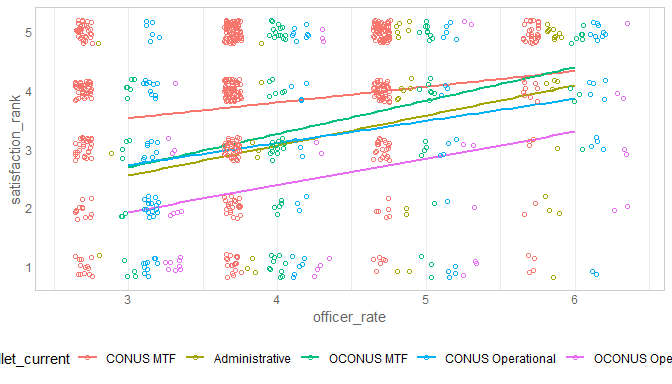

# 7 Ordinal Models

## 7.1 1-predictor ordinal model: billet

Data:`ds_no_other_or_unknown`  
Formula:

```
 ~
ordered(satisfaction_rank) billet_current
```

| term | estimate | std.error | statistic | coef.type |
| --- | --- | --- | --- | --- |
| billet_currentAdministrative | -0.1598301 | 0.2847549 | -0.5612903 | coefficient |
| billet_currentOCONUS MTF | -0.5408170 | 0.1975592 | -2.7374939 | coefficient |
| billet_currentCONUS Operational | -0.9174521 | 0.1903276 | -4.8203829 | coefficient |
| billet_currentOCONUS Operational | -1.8141170 | 0.3021047 | -6.0049280 | coefficient |
| 1\|2 | -2.3551770 | 0.1224293 | -19.2370433 | scale |
| 2\|3 | -1.6150921 | 0.1001752 | -16.1226674 | scale |
| 3\|4 | -0.7152669 | 0.0844094 | -8.4737827 | scale |
| 4\|5 | 0.3971137 | 0.0821859 | 4.8318944 | scale |

| edf | logLik | AIC | BIC | deviance | df.residual | nobs |
| --- | --- | --- | --- | --- | --- | --- |
| 8 | -1262.722 | 2541.445 | 2579.5 | 2525.445 | 852 | 860 |

## 7.2 1-predictor ordinal model: offier rate

Data:`ds_no_other_or_unknown`  
Formula:

```
 ~
ordered(satisfaction_rank) officer_rate
```

| term | estimate | std.error | statistic | coef.type |
| --- | --- | --- | --- | --- |
| officer_rate | 0.4972550 | 0.0666400 | 7.4618072 | coefficient |
| 1\|2 | 0.0181495 | 0.2869621 | 0.0632469 | scale |
| 2\|3 | 0.7415462 | 0.2826536 | 2.6235159 | scale |
| 3\|4 | 1.6279511 | 0.2856359 | 5.6993933 | scale |
| 4\|5 | 2.7581936 | 0.2963643 | 9.3067684 | scale |

| edf | logLik | AIC | BIC | deviance | df.residual | nobs |
| --- | --- | --- | --- | --- | --- | --- |
| 5 | -1259.639 | 2529.279 | 2553.058 | 2519.279 | 854 | 859 |

## 7.3 1-predictor ordinal model: specialty

Data:`ds_no_other_or_unknown`  
Formula:

```
 ~
ordered(satisfaction_rank) specialty_type
```

| term | estimate | std.error | statistic | coef.type |
| --- | --- | --- | --- | --- |
| specialty_typesurgical | -0.3465013 | 0.1714193 | -2.021366 | coefficient |
| specialty_typefamily | -0.7839712 | 0.1673401 | -4.684897 | coefficient |
| specialty_typeoperational | -1.6647223 | 0.2223020 | -7.488563 | coefficient |
| specialty_typeresident | -0.6376696 | 0.3092219 | -2.062175 | coefficient |
| 1\|2 | -2.4995064 | 0.1323535 | -18.885079 | scale |
| 2\|3 | -1.7510557 | 0.1114135 | -15.716735 | scale |
| 3\|4 | -0.8437125 | 0.0965107 | -8.742168 | scale |
| 4\|5 | 0.2778043 | 0.0924397 | 3.005250 | scale |

| edf | logLik | AIC | BIC | deviance | df.residual | nobs |
| --- | --- | --- | --- | --- | --- | --- |
| 8 | -1257.197 | 2530.395 | 2568.45 | 2514.395 | 852 | 860 |

## 7.4 3-predictor ordinal model

```
Call:
MASS::polr(formula = ordered(satisfaction_rank) ~ billet_current +
    officer_rate + specialty_type, data = ds_no_other_or_unknown)

Coefficients:
                                   Value Std. Error t value
billet_currentAdministrative     -0.6155    0.29779  -2.067
billet_currentOCONUS MTF         -0.5507    0.20021  -2.751
billet_currentCONUS Operational  -0.5241    0.23051  -2.274
billet_currentOCONUS Operational -1.6041    0.31659  -5.067
officer_rate                      0.4628    0.07274   6.363
specialty_typesurgical           -0.3982    0.17324  -2.299
specialty_typefamily             -0.5966    0.17200  -3.469
specialty_typeoperational        -0.8514    0.27879  -3.054
specialty_typeresident           -0.3633    0.32237  -1.127

Intercepts:
    Value   Std. Error t value
1|2 -0.7832  0.3277    -2.3899
2|3  0.0048  0.3214     0.0149
3|4  0.9711  0.3213     3.0225
4|5  2.1614  0.3285     6.5795

Residual Deviance: 2442.231
AIC: 2468.231
(77 observations deleted due to missingness)
```

Data:`ds_no_other_or_unknown`  
Formula:

```
 ~
ordered(satisfaction_rank) billet_current + officer_rate +
specialty_type
```

| term | estimate | std.error | statistic | coef.type |
| --- | --- | --- | --- | --- |
| billet_currentAdministrative | -0.6155252 | 0.2977934 | -2.0669541 | coefficient |
| billet_currentOCONUS MTF | -0.5507024 | 0.2002124 | -2.7505908 | coefficient |
| billet_currentCONUS Operational | -0.5240958 | 0.2305119 | -2.2736173 | coefficient |
| billet_currentOCONUS Operational | -1.6041125 | 0.3165904 | -5.0668382 | coefficient |
| officer_rate | 0.4628157 | 0.0727351 | 6.3630323 | coefficient |
| specialty_typesurgical | -0.3982413 | 0.1732421 | -2.2987560 | coefficient |
| specialty_typefamily | -0.5965928 | 0.1719977 | -3.4686098 | coefficient |
| specialty_typeoperational | -0.8513858 | 0.2787879 | -3.0538833 | coefficient |
| specialty_typeresident | -0.3633346 | 0.3223665 | -1.1270854 | coefficient |
| 1\|2 | -0.7831514 | 0.3276899 | -2.3899166 | scale |
| 2\|3 | 0.0047825 | 0.3214328 | 0.0148786 | scale |
| 3\|4 | 0.9710647 | 0.3212775 | 3.0225112 | scale |
| 4\|5 | 2.1613841 | 0.3285025 | 6.5795063 | scale |

| edf | logLik | AIC | BIC | deviance | df.residual | nobs |
| --- | --- | --- | --- | --- | --- | --- |
| 13 | -1221.116 | 2468.231 | 2530.056 | 2442.231 | 846 | 859 |

# 8 Models to Publish

## 8.1 3-predictor (and final) model

Data:`ds_no_other_or_unknown`  
Formula:

```
 ~
satisfaction_rank 1 + billet_current + officer_rate + specialty_type
```

| term | estimate | std.error | statistic | p.value |
| --- | --- | --- | --- | --- |
| (Intercept) | 2.7449416 | 0.2216697 | 12.3830259 | 0.0000000 |
| billet_currentAdministrative | -0.4449198 | 0.1985010 | -2.2413979 | 0.0252580 |
| billet_currentOCONUS MTF | -0.4035686 | 0.1380693 | -2.9229432 | 0.0035595 |
| billet_currentCONUS Operational | -0.3935332 | 0.1549743 | -2.5393446 | 0.0112834 |
| billet_currentOCONUS Operational | -1.1452059 | 0.2149465 | -5.3278645 | 0.0000001 |
| officer_rate | 0.2955084 | 0.0491857 | 6.0080167 | 0.0000000 |
| specialty_typesurgical | -0.2655425 | 0.1202900 | -2.2075190 | 0.0275446 |
| specialty_typefamily | -0.4094283 | 0.1188588 | -3.4446620 | 0.0005998 |
| specialty_typeoperational | -0.6634897 | 0.1855377 | -3.5760380 | 0.0003686 |
| specialty_typeresident | -0.1987343 | 0.2359798 | -0.8421669 | 0.3999317 |

| r.squared | adj.r.squared | sigma | statistic | p.value | df | logLik | AIC | BIC | deviance | df.residual | nobs |
| --- | --- | --- | --- | --- | --- | --- | --- | --- | --- | --- | --- |
| 0.1506291 | 0.1416252 | 1.256672 | 16.72926 | 0 | 9 | -1410.092 | 2842.184 | 2894.498 | 1340.762 | 849 | 859 |

Analysis of Variance Table

Model 1: satisfaction_rank ~ 1 + billet_current + officer_rate Model 2: satisfaction_rank ~ 1 + billet_current + officer_rate + specialty_type Res.Df RSS Df Sum of Sq F Pr(>F) 1 853 1373.5  
2 849 1340.8 4 32.789 5.1907 0.0003911

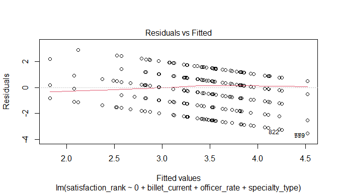

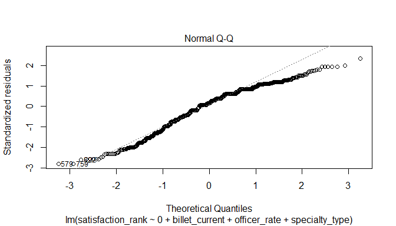

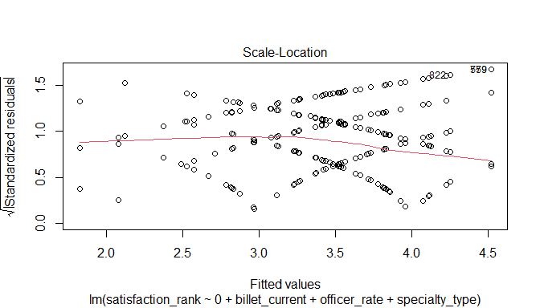

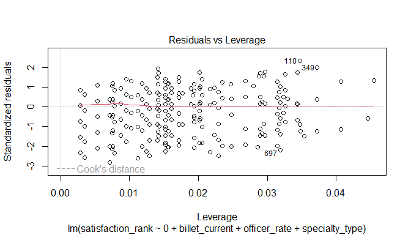

## 8.2 3-predictor model weight sampling weights

Data:`ds_no_other_or_unknown`  
Formula:

```
 ~
satisfaction_rank 1 + billet_current + officer_rate + specialty_type
```

| term | estimate | std.error | statistic | p.value |
| --- | --- | --- | --- | --- |
| (Intercept) | 2.5672108 | 0.2427369 | 10.5761050 | 0.0000000 |
| billet_currentAdministrative | -0.4852311 | 0.2196834 | -2.2087744 | 0.0274568 |
| billet_currentOCONUS MTF | -0.2645507 | 0.1663384 | -1.5904370 | 0.1121086 |
| billet_currentCONUS Operational | -0.2267988 | 0.1489326 | -1.5228285 | 0.1281740 |
| billet_currentOCONUS Operational | -1.0832312 | 0.2116975 | -5.1168828 | 0.0000004 |
| officer_rate | 0.3307020 | 0.0525848 | 6.2889212 | 0.0000000 |
| specialty_typesurgical | -0.2780756 | 0.1284607 | -2.1646746 | 0.0306907 |
| specialty_typefamily | -0.4330843 | 0.1660709 | -2.6078272 | 0.0092719 |
| specialty_typeoperational | -0.7198543 | 0.1616156 | -4.4541130 | 0.0000096 |
| specialty_typeresident | -0.1449924 | 0.1527102 | -0.9494615 | 0.3426561 |

| r.squared | adj.r.squared | sigma | statistic | p.value | df | logLik | AIC | BIC | deviance | df.residual | nobs |
| --- | --- | --- | --- | --- | --- | --- | --- | --- | --- | --- | --- |
| 0.1853017 | 0.1766653 | 2.545062 | 21.45595 | 0 | 9 | -1528.984 | 3079.968 | 3132.282 | 5499.261 | 849 | 859 |

## 8.3 Billet Intercepts

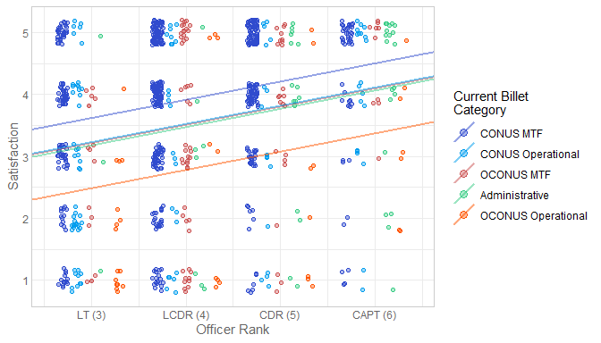

## 8.4 Specialty Intercepts

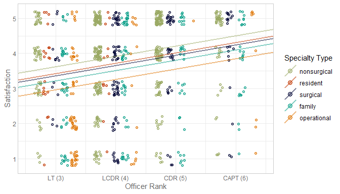

## 8.5 Nonsignificant Additions

```
The `officer_rate * specialty_type`  interaction doesn't sig improve the fit of the model
```

```
Analysis of Variance Table

Model 1: satisfaction_rank ~ 1 + billet_current + officer_rate + specialty_type
Model 2: satisfaction_rank ~ 1 + billet_current + officer_rate * specialty_type
  Res.Df    RSS Df Sum of Sq      F Pr(>F)
1    849 1340.8
2    845 1336.7  4    4.0491 0.6399 0.6341
```

```
`manning_proportion_cut3` doesn't sig improve the fit of the model
```

```
Analysis of Variance Table

Model 1: satisfaction_rank ~ 1 + billet_current + officer_rate + specialty_type
Model 2: satisfaction_rank ~ 1 + billet_current + officer_rate + specialty_type +
    manning_proportion_cut3
  Res.Df    RSS Df Sum of Sq      F Pr(>F)
1    849 1340.8
2    847 1339.9  2   0.88131 0.2786 0.7569
```

```
`bonus_pay_cut4` doesn't sig improve the fit of the model
```

```
Analysis of Variance Table

Model 1: satisfaction_rank ~ 1 + billet_current + officer_rate + specialty_type
Model 2: satisfaction_rank ~ 1 + billet_current + officer_rate + specialty_type +
    bonus_pay_cut4
  Res.Df    RSS Df Sum of Sq    F Pr(>F)
1    849 1340.8
2    846 1336.5  3    4.2181 0.89 0.4458
```

# 9 Session Information

For the sake of documentation and reproducibility, the current report was rendered in the following environment. Click the line below to expand.

Report rendered by wibea at 2023-04-06, 18:04 -0500 in 7 seconds.